# Modelos de ecuaciones estructurales

https://github.com/fedediazr/Clase-SEM-fdr

Federico Díaz Recart

## Contenidos

- Introducción
- Modelo de medición
  - Error de medición
  - Variable latente
  - CFA (Análisis factorial confirmatorio)
- Modelo estructural
  - Path analysis (Variables observadas)
  - Modelo de ecuaciones estructurales: Combinación entre modelo de medición y modelo estructural

## Introducción: ¿Qué es SEM?

Más que una técnica, los modelos de ecuaciones estructurales son una familia de métodos que combinan:

1. **Modelos de medición**: Permiten medir y evaluar como se relacionan un conjunto de variables observadas y si estas miden un constructo teórico de interés
2. **Modelos estructurales**: Permite evaluar si un conjunto de constructos se relacionan según un modelo teórico propuesto

Es un conjunto de métodos comprensivos para la cuantificación y testeo de **teorías sustantivas**

## Ejemplo: Normas sociales y polarización

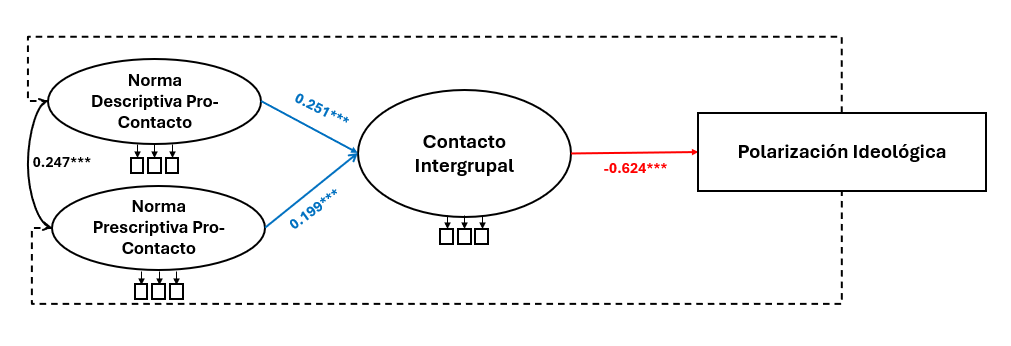

González, R., Díaz, F., Fuenzalida, D., Álvarez, A., Lay, S., Carvacho, H., & Manzi, J. (2025, May 22–23). Social norms and affective polarization in political contexts [Conference presentation]. Interdisciplinary Conference on Social Norms, Cohesion, and (De)Polarization, Utrecht, Netherlands.

## 1: Modelo de medición

## Error de medición

Una de las características más importantes de los modelos SEM es que **toman en cuenta el error de medición**.

Dos fuentes de error en encuestas: Medición (cómo se mide el fenómeno) y Representación (a quiénes se logra medir).

- Medición: El constructo teórico que se quiere medir se transforma en preguntas (operacionalización). Las respuestas pueden verse afectadas por problemas de validez, error de medición y error de procesamiento.

## Error de medición

- Representación: Desde la población objetivo se define una población inferencial, un marco muestral y una muestra. En cada paso pueden surgir errores de cobertura, muestreo y no respuesta.

Modelos SEM nos permiten separar la varianza asociada al puntaje “real” de un constructo de la varianza asociada a error de medición.

## Error de medición

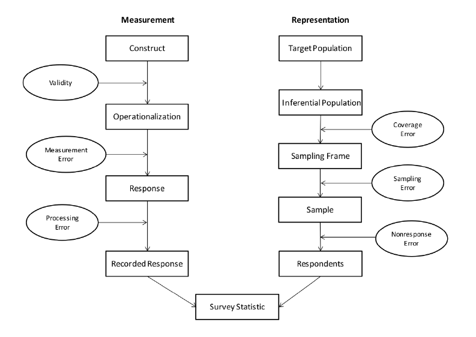

Total survey error approach

## Error de medición

Por lo tanto, indicadores individuales pueden ser insuficientes para medir conceptos complejos, especialmente en ciencias sociales:

- Clase social
- Confianza social
- Actitudes hacia la democracia
- Actitudes punitivas
- Creencia en conspiraciones
- Bienestar subjetivo

## Variable latente

¿Cómo los modelos SEM corrigen el error de medición?

- SEM utiliza variables latentes (constructos no observados, p. ej., inteligencia).
- Estas se estiman a partir de múltiples variables observadas (ítems, puntajes).
- Separa la parte confiable (puntaje verdadero) del error de medición.
- Modela relaciones entre constructos libres de error. Entregando estimaciones menos sesgadas que usar variables observadas directamente.

## Variable latente

¿Qué es una variable latente?

- Constructos teóricos no observados y que no pueden ser medidos directamente pero que existen
- Son “inferidas” a través de múltiples variables que actúan como manifestaciones del constructo.
- Por ejemplo, no podemos medir directamente depresión, pero podemos aproximarnos a través de la medición de distintos síntomas (PHQ9).

## Variable latente

[figure not shown]

## Análisis factorial confirmatorio

- Técnica multivariante de análisis de interdependencia entre variables
- Permite estudiar interrelación de un número de variables **observadas**
- Estas variables se agrupan en un número reducido de factores (variable latente)
- Validación de instrumentos
- Derivación de puntajes

## Análisis factorial confirmatorio

Ejemplo aplicado: ¿Corresponden las normas descriptivas pro contacto y las normas prescriptivas pro contacto a dos dimensiones distintas?

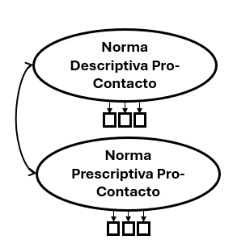

## Variables

Indique el grado de acuerdo o desacuerdo con las siguientes afirmaciones

- Las personas de **[INGROUP]** que conozco valorarían que yo tenga amistades de **[OUTGROUP]**.
- Las personas de **[INGROUP]** que conozco me estimulan a que me junte con personas de **[OUTGROUP]**.
- Las personas de **[INGROUP]** que conozco valorarían que yo colabore con personas de **[OUTGROUP]**.
- Es común que las personas de **[INGROUP]** tengan amistades de **[OUTGROUP]**.
- Con frecuencia las personas de **[INGROUP]** se juntan con personas de **[OUTGROUP]**.
- Con frecuencia las personas de **[INGROUP]** colaboran con personas de **[OUTGROUP]**.

## Pasos

1. Especificación del modelo
2. Evaluación de ajuste
3. Cargas factoriales

## Especificación del modelo

```r
load("Base_polarizacion_escalas.Rdata")
library(lavaan)
cfa <- '

# -----------------------------------------------
# Variables latentes
# -----------------------------------------------
norm_descr_pro_cont =~ Q10_1 + Q10_2 + Q10_3
norm_pres_pro_cont =~ Q15_1 + Q15_2 + Q15_3

# Covarianza
norm_descr_pro_cont ~~ norm_pres_pro_cont
'

fit_cfa <- cfa(cfa, data = df)
```

- el operador =~ significa “es manifestado por”
- Tenemos 2 variables latentes, manifestadas por 3 items cada una
- Para ajustar el modelo utilizamos el comando cfa

## Ajuste del modelo

```r
fitMeasures(fit_cfa, c("chisq", "df", "pvalue", "cfi", "rmsea", "tli"))
```

```
 chisq     df pvalue    cfi  rmsea    tli
41.392  8.000  0.000  0.978  0.084  0.958
```

- χ² (p < .05): indica discrepancia significativa, pero es sensible al tamaño muestral.
- CFI (.978): muy buen ajuste del modelo.
- TLI (.958): buen ajuste, penaliza complejidad.
- RMSEA (.084): ajuste aceptable–limítrofe.

Conclusión: ajuste global bueno, pese al χ² significativo.

## Cargas factoriales

- Las cargas factoriales indican qué tan fuertemente cada ítem observado está asociado con el factor latente que pretende medir.
- Es el coeficiente de regresión que indica cuánto cambia el ítem cuando el factor aumenta una unidad.

```r
loadings <- inspect(fit_cfa, what = "std")$lambda
loadings
```

```
      nrm_d__ nrm_p__
Q10_1   0.785   0.000
Q10_2   0.915   0.000
Q10_3   0.713   0.000
Q15_1   0.000   0.777
Q15_2   0.000   0.721
Q15_3   0.000   0.781
```

- Todas son altas (≈ .71–.92), indicando que los ítems representan bien sus factores latentes.

## 2: Modelo estructural

## Path analysis (Análisis de senderos)

- Es un modelo de relaciones de dependencia entre varias variables
- Utiliza variables observadas o promedios de ítemes
- No evalúa un modelo de medición

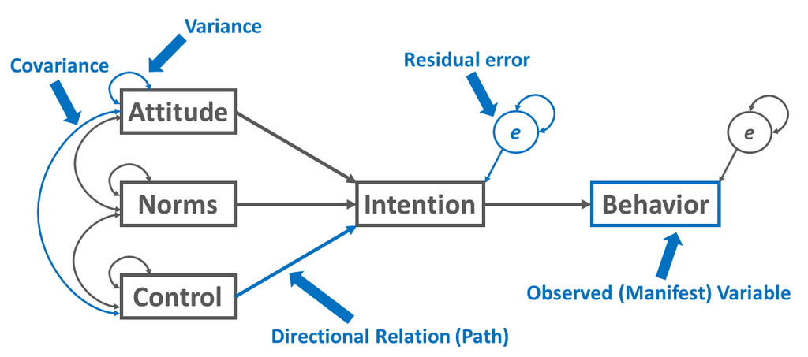

Caughlin, D. E. (2022). R for HR: An introduction to human resource analytics using R.

## Path analysis (Análisis de senderos)

- Es una extensión de la regresión lineal
- Incorpora varias regresiones en un mismo modelo, permitiendo evaluar
  - Efectos directos
  - Efectos indirectos
  - Mediación y efectos totales

## Path analysis (Análisis de senderos)

### Supuestos

- Tamaño de muestra grande: Al menos 10 a 20 casos por parametro, idealmente N>200
- Relaciones lineales entre variables
- Identificación del modelo basado en teoría
- Variables continuas

## Modelo de ecuaciones estructurales

- Combinan modelo de medición y modelo estructural
- Hoy nos vamos a fijar en modelos que combinan análisis de senderos con análisis factorial confirmatorio
- En síntesis: Análisis de senderos de variables latentes y observadas
- Estos modelos son también llamados modelos MIMIC (Multiple Indicators Multiple Causes)

## Modelo de ecuaciones estructurales

### Efecto directo, indirecto y total

- Efecto directo: influencia de una variable sobre otra sin mediadores (por ejemplo, 𝑋→𝑌
- Efecto indirecto: influencia de una variable sobre otra que ocurre a través de una o más variables mediadoras (por ejemplo, 𝑋→𝑀→𝑌)
  - Matemáticamente, es el producto de los coeficientes de los caminos involucrados (ej.: 𝑎×𝑏)
- Efecto total: efecto global de una variable sobre otra, que combina todas las vías posibles.

## Modelo de ecuaciones estructurales

### Supuestos

- Tamaño de muestra grande: Al menos 10 a 20 casos por parametro, idealmente N>200
- Relaciones lineales entre variables
- Identificación del modelo basado en teoría
- Variables continuas

## Modelo de ecuaciones estructurales

### Especificación del modelo

Cupani (2012) sugiere varias estrategias posibles:

1. Modelización confirmatoria: Se especifica un solo modelo alineado con lo que se espera teóricamente.
2. Modelos rivales: Se especifican varios modelos distintos para que “compitan” en términos de ajuste
3. Desarrollo del modelo: Se parte de un modelo simple y se va mejorando, ya sea el modelo de medición o las relaciones estructurales entre variables

## Modelo de ecuaciones estructurales

### Evaluación del ajuste

Igual que en los modelos CFA

- Chi cuadrado
- RMSEA
- CFI

## Modelo de ecuaciones estructurales

### Interpretación de resultados

- Coeficientes beta no estandarizados: Efecto que cada aumento en una unidad de la variable independiente tiene en la dependiente
- Coeficientes beta estandarizados: Efectos que cada aumento en una desviación estándar de la variable independiente tiene en la dependiente (en términos de desviaciones estándar)
- Significación de cada coeficiente: p<0,05, rechazamos hipótesis nula de que el beta es igual a 0 a un 95% de confianza

## Ejemplo aplicado

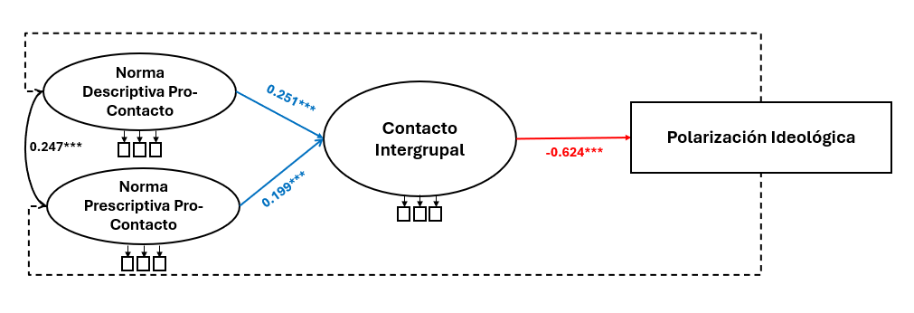

González, R., Díaz, F., Fuenzalida, D., Álvarez, A., Lay, S., Carvacho, H., & Manzi, J. (2025, May 22–23). Social norms and affective polarization in political contexts [Conference presentation]. Interdisciplinary Conference on Social Norms, Cohesion, and (De)Polarization, Utrecht, Netherlands.

## Ejemplo aplicado

### Variables

- Normas prescriptivas pro contacto (ej: “Las personas de [INGROUP] que conozco valoran tener amistades con gente de [OUTGROUP])
- Normas descriptivas pro contacto (ej: “Es común que las personas de [INGROUP] tengan amistades de [OUTGROUP])
- Contacto intergrupal (ej: ¿Con qué frecuencia interactúa con personas de [OUTGROUP])
- Polarización ideológica: Medida como la distancia del punto medio en una serie de problemáticas (Aborto, conflicto indígena, rol estado vs empresa)

## Especificación del modelo

```r
m1 <- '

## -----------------------------------------------
# Variables latentes
# -----------------------------------------------
norm_descr_c =~ Q10_1 + Q10_2 + Q10_3
norm_prescr_c =~ Q15_1 + Q15_2 + Q15_3
contact =~ Cantidad_contacto + Contacto_positivo

# -----------------------------------------------
# Relaciones estructurales (Mediación)
# -----------------------------------------------
# Efecto de normas descriptivas y prescriptivas sobre contact (a)
contact ~ a*norm_descr_c + a2*norm_prescr_c

# Efecto de contact sobre polarización (b)
id_pol ~ b*contact + c*norm_descr_c + c2*norm_prescr_c

# Covarianza
norm_descr_c ~~ norm_prescr_c

# Covarianza items
Q10_1 ~~ Q15_1
Q10_2 ~~ Q15_2
Q10_3 ~~ Q15_3

# -----------------------------------------------
# Efectos definidos (Indirecto y Total)
# -----------------------------------------------
indirect1 := a*b
indirect3 := a2*b

total1 := a * b + c
total3 := a2 * b + c2
'

fit_m1 <- sem(m1, data = df, missing="FIML")
```

## Interpretación de resultados

```r
summary(fit_m1, fit.measures = TRUE, standardized = TRUE)
```

```
lavaan 0.6-19 ended normally after 61 iterations

  Estimator                                         ML
  Optimization method                           NLMINB
  Number of model parameters                        35

  Number of observations                           591
  Number of missing patterns                         5

Model Test User Model:

  Test statistic                                47.394
  Degrees of freedom                                19
  P-value (Chi-square)                           0.000

Model Test Baseline Model:

  Test statistic                              1745.124
  Degrees of freedom                                36
  P-value                                        0.000

User Model versus Baseline Model:

  Comparative Fit Index (CFI)                    0.983
  Tucker-Lewis Index (TLI)                       0.969

  Robust Comparative Fit Index (CFI)             0.983
  Robust Tucker-Lewis Index (TLI)                0.968

Loglikelihood and Information Criteria:

  Loglikelihood user model (H0)              -6191.029
  Loglikelihood unrestricted model (H1)      -6167.332

  Akaike (AIC)                               12452.058
  Bayesian (BIC)                             12605.422
  Sample-size adjusted Bayesian (SABIC)      12494.308

Root Mean Square Error of Approximation:

```

[output cut: 75 more lines]

```
   .Q15_2             0.325    0.026   12.351    0.000    0.325    0.473
   .Q15_3             0.333    0.030   10.989    0.000    0.333    0.406
   .Cantidad_cntct    0.120    0.051    2.369    0.018    0.120    0.288
   .Contacto_postv    0.650    0.047   13.906    0.000    0.650    0.805
   .id_pol            2.227    0.136   16.385    0.000    2.227    0.955
    norm_descr_c      0.508    0.049   10.462    0.000    1.000    1.000
    norm_prescr_c     0.409    0.041    9.891    0.000    1.000    1.000
   .contact           0.222    0.051    4.373    0.000    0.748    0.748

Defined Parameters:
                   Estimate  Std.Err  z-value  P(>|z|)   Std.lv  Std.all
    indirect1        -0.175    0.067   -2.627    0.009   -0.125   -0.082
    indirect3        -0.115    0.055   -2.087    0.037   -0.074   -0.048
    total1           -0.188    0.118   -1.594    0.111   -0.134   -0.088
    total3            0.108    0.137    0.784    0.433    0.069    0.045
```

# ¡Gracias!

fdr@alumni.uc.cl